# Programación funcional

Sesión 1

Luis F. Gomez L.

luis.gomezl@unimilitar.edu.co

Facultad de Estudios a Distancia

2026-11-12

# Preliminares

- Verificar:
  - ¿La carpeta `data` fue creada?
  - ¿El archivo `2021-saber_pro-genericas.txt.xz` fue incluido en `data`?
- Generar carpetas:
  - `019_funciones-anonimas-purrr-en-r`
    - Crear archivo `001_funciones-anonimas-purrr.R`
  - `020_funciones-map-reduce-list-rbind-en-r`
    - Crear archivo `001_funciones-map-reduce-list-rbind.R`
- Descargar datos:
  - `2022-saber_pro-genericas.txt.xz`
  - `2023-saber_pro-genericas.txt.xz`
  - `2024-saber_pro-genericas.txt.xz`
    - Agregar en `data`

# Funciones anónimas y `purrr`

## `purrr`

- Paquete del `tidyverse` diseñado para facilitar la **programación funcional** en R (Wickham 2023, cap. 26).
- Sustituye los bucles imperativos (`for`, `while`) por **funcionales** (funciones de orden superior que reciben funciones como argumentos) (Wickham 2019, cap. 9).
- Permite expresar directamente **qué** transformación aplicar a cada elemento en vez de gestionar **cómo** controlar los índices y la inicialización de variables.
- Conduce a un código más conciso, legible, expresivo y fácil de depurar.

## Vectores

- Estructura de datos más básica e importante en R (Wickham 2019, cap. 3), clasificada en:
  - **Vectores atómicos**: unidimensionales y homogéneos (`logical`, `integer`, `double`, `character`). Si se combinan tipos con `c()`, R aplica coerción implícita.
  - **Listas**: unidimensionales y heterogéneas. Cada elemento puede ser de distinto tipo y longitud (vectores, funciones, tablas `tibble`).
- **Comportamiento clave con tablas de datos:**
  - `list(tibble(...), tibble(...))` conserva cada tabla independiente (`[[1]]` y `[[2]]`).
  - `c(tibble(...), tibble(...))` descompone y aplana las columnas perdiendo la identidad tabular.

## `list()` vs. `c()` con `tibble`s

**`list()`: preserva la estructura tabular**

```r
list(
  tibble(x = "a", y = "b"),
  tibble(y = "c", z = "d")
)
```

```
[[1]]
# A tibble: 1 × 2
  x     y
  <chr> <chr>
1 a     b

[[2]]
# A tibble: 1 × 2
  y     z
  <chr> <chr>
1 c     d
```

**`c()`: aplana y descompone en columnas**

```r
c(
  tibble(x = "a", y = "b"),
  tibble(y = "c", z = "d")
)
```

```
$x
[1] "a"

$y
[1] "b"

$y
[1] "c"

$z
[1] "d"
```

## Funciones

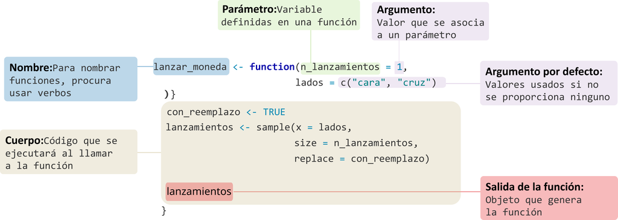

Figura 1: Estructura de una función en R (Grolemund 2014, cap. 1)

- **Nombre**: identificador asignado con `<-` para almacenarla en el entorno.
- **Parámetros y argumentos**: variables declaradas en `function(...)` y argumentos por defecto.
- **Cuerpo (`{ ... }`) y salida**: bloque de instrucciones; R retorna automáticamente la última expresión evaluada.

## `lanzar_moneda()`

```r
# Función completa parametrizada ----
lanzar_moneda <- function(
  n_lanzamientos = 1,
  lados = c("cara", "cruz")
) {
  # Variable auxiliar
  con_reemplazo <- TRUE

  lanzamientos <- sample(
    x = lados,
    size = n_lanzamientos,
    replace = con_reemplazo
  )

  # Salida
  lanzamientos
}
```

```r
# Con argumentos por defecto ----
lanzar_moneda()
```

```
[1] "cara"
```

```r
# Especificando argumentos ----
lanzar_moneda(n_lanzamientos = 5)
```

```
[1] "cruz" "cara" "cara" "cruz" "cruz"
```

## Funciones anónimas

- Funciones que no tienen un nombre asignado con `<-` (lambdas) (Wickham 2019, cap. 9).
- Ideales para transformaciones breves de un solo uso dentro de funcionales de `purrr`, evitando sobrecargar el entorno global con funciones intermedias.
- **Sintaxis nativa** (a partir de R `4.1.0`):

  ```r
  \(x) { ... } # Equivalente a function(x) { ... }
  ```

- Existen únicamente en el contexto de la expresión donde se evalúan (p. ej. pasadas al argumento `.f` en `map()`).

## `\(x) { ... }`

```r
# Función anónima nativa ----
\(x) {
  sample(
    x = c("cara", "cruz"),
    size = x,
    replace = TRUE
  )
}
```

```r
# Invocación inmediata ----
(\(x) {
  sample(
    x = c("cara", "cruz"),
    size = x,
    replace = TRUE
  )
})(3)
```

```
[1] "cruz" "cara" "cara"
```

## `map()`

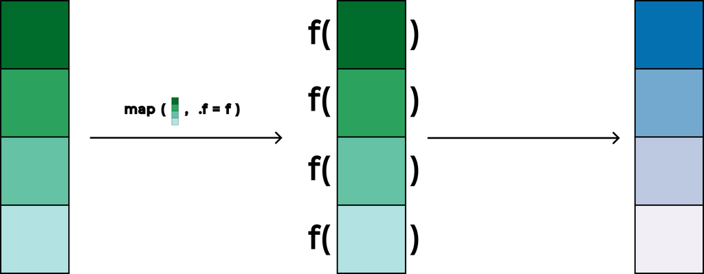

Figura 2: Representación gráfica de la función `map()` (Wickham 2023, cap. 26)

- **Propósito**: transforma un vector aplicando una función individual a cada uno de sus elementos.
- **Argumentos**: `.x` (vector atómico o lista a iterar) y `.f` (función nombrada o anónima `\(x)`).
- **Resultado**: **siempre retorna una lista** con la misma longitud que el vector `.x`.

## `map()` con función nombrada y anónima

**Con función nombrada (`lanzar_moneda`)**

```r
# Iteración con función nombrada ----
map(
  .x = 1:3,
  .f = lanzar_moneda
)
```

```
[[1]]
[1] "cara"

[[2]]
[1] "cara" "cara"

[[3]]
[1] "cara" "cara" "cara"
```

**Con función anónima (`\(x) { ... }`)**

```r
# Iteración con función anónima ----
map(
  .x = 1:3,
  .f = \(x) {
    sample(
      x = c("cara", "cruz"),
      size = x,
      replace = TRUE
    )
  }
)
```

```
[[1]]
[1] "cara"

[[2]]
[1] "cruz" "cara"

[[3]]
[1] "cruz" "cruz" "cruz"
```

## `reduce()`

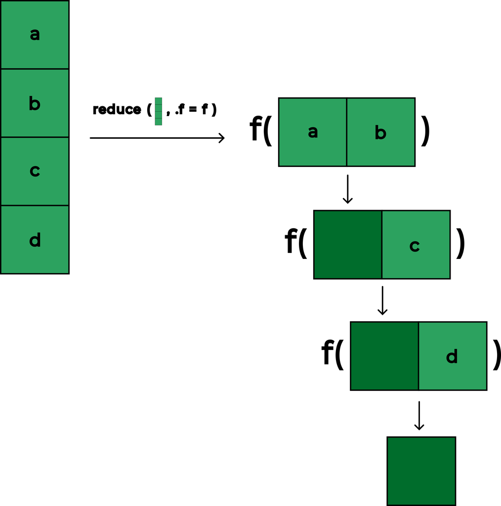

Figura 3: Representación gráfica de la función `reduce()` (Wickham 2023, cap. 26)

- **Propósito**: combina progresivamente los elementos de una colección hasta consolidar un **único valor**.
- **Argumentos**: `.x` (vector o lista) y `.f` (**función binaria** de dos entradas, p. ej. `intersect()`, `+`).
- **Mecanismo**: acumulativo y secuencial: $f(a, b) \rightarrow f(\text{resultado}, c) \rightarrow \dots$

## `reduce()` con `intersect()`

- **Intersección múltiple**:
  - `intersect()` de R base solo compara **dos** vectores a la vez.
  - `reduce()` permite extenderla a cualquier cantidad de conjuntos en una lista.
- **Paso a paso acumulativo**:
  1. $f(\text{conjunto 1}, \text{conjunto 2})$: `intersect(c("A","B","C"), c("B","C","D"))` $\rightarrow$ `c("B", "C")`
  2. $f(\text{resultado}, \text{conjunto 3})$: `intersect(c("B","C"), c("C","D","E"))` $\rightarrow$ `"C"`

```r
# Lista de conjuntos ----
conjuntos <- list(
  c("A", "B", "C"),
  c("B", "C", "D"),
  c("C", "D", "E")
)

# Intersección acumulativa ----
reduce(
  .x = conjuntos,
  .f = intersect
)
```

```
[1] "C"
```

## `list_rbind()`

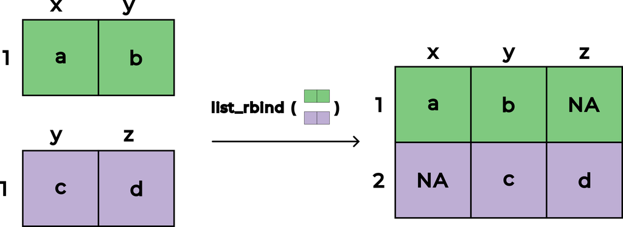

Figura 4: Representación gráfica de la función `list_rbind()` (Wickham 2023, cap. 26)

- **Propósito**: apila verticalmente por filas una lista de `tibble`s en una única tabla rectangular.
- **Alineación por nombres**: une columnas coincidentes y preserva las no compartidas imputando `NA`.
- **Flujo en análisis**: clave tras importar múltiples archivos con `map()` para unificarlos en un solo conjunto.

## `list_rbind()` con `tibble`s

- **Consolidación rectangular**:
  - Al procesar múltiples archivos con `map()`, el resultado es una **lista** de tablas individuales.
  - `list_rbind()` las reúne en un único `tibble` consolidado.
- **Alineación por nombres**:
  - Columna común `y`: se concatena verticalmente.
  - Columnas `x` y `z`: se conservan e imputa `NA` donde no existían.

```r
# Lista de tablas con columnas parcialmente coincidentes ----
tablas_datos <- list(
  tibble(x = "a", y = "b"),
  tibble(y = "c", z = "d")
)

# Unión por filas ----
list_rbind(tablas_datos)
```

```
# A tibble: 2 × 3
  x     y     z
  <chr> <chr> <chr>
1 a     b     <NA>
2 <NA>  c     d
```

# Funciones `map()`, `reduce()` y `list_rbind()`

## Exploración del sistema de archivos con `fs`

- Al trabajar con **datos históricos**, la información suele encontrarse fragmentada en múltiples archivos dentro de un mismo directorio (p. ej. un archivo por año o periodo) (Wickham 2023, cap. 26).
- El paquete **`fs`** ofrece una interfaz homogénea, consistente e independiente del sistema operativo para gestionar rutas y archivos, integrándose naturalmente con el operador `|>` y el `tidyverse`.

## Exploración del sistema de archivos con `fs`

- La función **`dir_ls()`** permite listar los contenidos aplicando criterios de filtrado:
  - **`path`**: ruta del directorio a explorar (`"data/"`).
  - **`type = "file"`**: restringe la búsqueda exclusivamente a archivos, descartando subcarpetas.
  - **`glob = "*.txt.xz$"`**: patrón comodín (*wildcard*):
    - `*`: comodín para representar cualquier secuencia de caracteres (p. ej. `2021-saber_pro-genericas`).
    - `.txt.xz`: extensión compuesta de texto plano comprimido.
    - `$`: ancla la búsqueda garantizando que termine con esa extensión exacta.

## Identificación de rutas de archivos con `dir_ls()`

```r
# Cargar paquetes ----
library(tidyverse)
library(fs)

# Rutas ----
paths <- dir_ls(
  path = "data/",
  type = "file",
  glob = "*.txt.xz$"
)

paths
```

```
../data/2021-saber_pro-genericas.txt.xz ../data/2022-saber_pro-genericas.txt.xz
../data/2023-saber_pro-genericas.txt.xz ../data/2024-saber_pro-genericas.txt.xz
```

## Importación inicial con `map()`

- Con el vector de rutas `paths`, se realiza una importación iterativa aplicando **`map()`** junto con una **función anónima** `\(x)`.
- Como los microdatos del ICFES utilizan el punto y coma (`;`) como delimitador, la función adecuada de lectura es **`read_csv2()`**.
- El resultado es una **lista con 4 tibbles** correspondientes a 2021, 2022, 2023 y 2024.
- **Discrepancia en columnas**:
  - Al inspeccionar las tablas se evidencia que no todas contienen el mismo número de variables:
    - **2021**: 95 variables.
    - **2022**: 100 variables.
    - **2023**: 96 variables.
    - **2024**: 90 variables.

## Importación inicial con `map()`

```r
# Importación inicial ----
saber_pro_genericas_2021_2024 <- paths |>
  map(
    .f = \(x) {
      read_csv2(
        file = x
      )
    }
  )

# Número de columnas por archivo ----
saber_pro_genericas_2021_2024 |>
  map(
    .f = ncol
  )
```

```
$`../data/2021-saber_pro-genericas.txt.xz`
[1] 95

$`../data/2022-saber_pro-genericas.txt.xz`
[1] 100

$`../data/2023-saber_pro-genericas.txt.xz`
[1] 96

$`../data/2024-saber_pro-genericas.txt.xz`
[1] 90
```

## Identificación de variables comunes

- Para unificar estas tablas en una sola estructura rectangular homogénea, es indispensable identificar cuáles columnas están presentes en la **totalidad de los archivos anuales**.
- **Estrategia con programación funcional**:
  1. Extraer los nombres de las variables de cada tabla aplicando `map()` con la función `names`:
     $$\text{map}(.f = \text{names})$$
  2. Aplicar la función binaria `intersect()` de forma acumulativa sobre la lista de nombres mediante `reduce()`:
     $$\text{reduce}(.f = \text{intersect})$$
- Como resultado de la evaluación, se obtiene el vector `variables_completas` que contiene las **82 variables comunes** a los 4 años.

## Variables comunes con `map()` y `reduce()`

```r
# Identificación variables completas ----
variables_completas <- saber_pro_genericas_2021_2024 |>
  map(
    .f = names
  ) |>
  reduce(
    .f = intersect
  )

variables_completas
```

```
 [1] "periodo"                       "estu_consecutivo"
 [3] "estu_estudiante"               "estu_tipodocumento"
 [5] "estu_nacionalidad"             "estu_actividadrefuerzoareas"
 [7] "estu_actividadrefuerzogeneric" "estu_agregado"
 [9] "estu_cod_depto_presentacion"   "estu_cod_mcpio_presentacion"
```

## Selección estricta con `all_of()`

- Al reimportar mediante `col_select = all_of(variables_completas)`, la función auxiliar **`all_of()`** cumple 2 propósitos fundamentales:
  - **Resolución explícita de variables de entorno**:
    - Cuando se suministra un vector de caracteres definido en el entorno de trabajo como `variables_completas`, envolverlo en `all_of()` le indica a R de forma inequívoca que debe evaluar su contenido como los nombres de las columnas.
  - **Validación estricta de columnas**:
    - `all_of()` exige que **todas** las columnas especificadas en el vector existan en el archivo; si falta alguna, interrumpe la ejecución con error.

## Diagnóstico y ajuste de tipos de columnas

- Al examinar las especificaciones inferidas por `readr` mediante `spec()`, se identifican variables que requieren ajuste explícito:
  1. **`periodo`**: inferida como numérica continua (`col_double()`), pero corresponde a un código cronológico compuesto (ej. `"20212"`) que debe dividirse posteriormente $\rightarrow$ `col_character()`.
  2. **Códigos geográficos e institucionales** (`estu_cod_depto_presentacion`, `estu_cod_mcpio_presentacion`, `estu_inst_codmunicipio`, `estu_prgm_codmunicipio`): inferidos como `col_double()`, lo que causa la pérdida de ceros a la izquierda (ej. `"05"` de Antioquia pasa a `5`) alterando el estándar DIVIPOLA $\rightarrow$ `col_character()`.

## Diagnóstico y ajuste de tipos de columnas

3. **`estu_fechanacimiento`**: fechas en formato día/mes/año (`DD/MM/AAAA`) $\rightarrow$ `col_date(format = "%d/%m/%Y")`.
4. **`estu_snies_prgmacademico` e `inst_cod_institucion`**: identificadores discretos $\rightarrow$ `col_integer()`.
- La función **`cols()`** de `readr` permite sobreescribir únicamente estas 8 columnas, dejando inferir automáticamente las 74 restantes.

## Importación y verificación

```r
# Ajuste especificación variables ----
saber_pro_genericas_2021_2024 <- paths |>
  map(
    .f = \(x) {
      read_csv2(
        file = x,
        col_types = cols(
          periodo = col_character(),
          estu_cod_depto_presentacion = col_character(),
          estu_cod_mcpio_presentacion = col_character(),
          estu_fechanacimiento = col_date(format = "%d/%m/%Y"),
          estu_inst_codmunicipio = col_character(),
          estu_prgm_codmunicipio = col_character(),
          estu_snies_prgmacademico = col_integer(),
          inst_cod_institucion = col_integer()
        ),
        col_select = all_of(variables_completas)
      )
    }
  )

# Chequeo problemas ----
saber_pro_genericas_2021_2024 |>
  map(
    .f = problems
  )
```

```
$`../data/2021-saber_pro-genericas.txt.xz`
# A tibble: 0 × 5
# ℹ 5 variables: row <int>, col <int>, expected <chr>, actual <chr>, file <chr>

$`../data/2022-saber_pro-genericas.txt.xz`
# A tibble: 0 × 5
# ℹ 5 variables: row <int>, col <int>, expected <chr>, actual <chr>, file <chr>

$`../data/2023-saber_pro-genericas.txt.xz`
# A tibble: 0 × 5
# ℹ 5 variables: row <int>, col <int>, expected <chr>, actual <chr>, file <chr>

$`../data/2024-saber_pro-genericas.txt.xz`
# A tibble: 0 × 5
# ℹ 5 variables: row <int>, col <int>, expected <chr>, actual <chr>, file <chr>
```

## Unión por filas con `list_rbind()`

- Con los 4 archivos importados bajo la misma estructura (82 columnas comunes y tipos de datos normalizados), el objeto `saber_pro_genericas_2021_2024` consiste en una lista con 4 tablas independientes.
- Para realizar análisis consolidados sobre el periodo 2021-2024, se concatenan verticalmente todas las filas en un único conjunto de datos rectangular.
- La función **`list_rbind()`** del paquete `purrr`:
  - Recibe la lista de tibbles y apila sus filas en una sola tabla.
  - La totalidad de observaciones correspondientes a los 4 años quedan consolidadas en una única tibble de 82 columnas.

## Consolidación con `list_rbind()`

```r
# Unión filas ----
saber_pro_genericas_2021_2024 <- saber_pro_genericas_2021_2024 |>
  list_rbind()

saber_pro_genericas_2021_2024
```

```
# A tibble: 1,015,295 × 82
   periodo estu_consecutivo estu_estudiante estu_tipodocumento estu_nacionalidad
   <chr>   <chr>            <chr>           <chr>              <chr>
 1 20212   EK202120193457   ESTUDIANTE      CC                 COLOMBIA
 2 20212   EK202120140653   ESTUDIANTE      CC                 COLOMBIA
 3 20212   EK202120232447   ESTUDIANTE      CC                 COLOMBIA
 4 20212   EK202120162182   ESTUDIANTE      CC                 COLOMBIA
 5 20212   EK202120172982   ESTUDIANTE      CC                 COLOMBIA
 6 20212   EK202120096937   ESTUDIANTE      CC                 COLOMBIA
 7 20212   EK202120141225   ESTUDIANTE      CC                 COLOMBIA
 8 20212   EK202120122080   ESTUDIANTE      CC                 COLOMBIA
 9 20212   EK202120147209   ESTUDIANTE      CC                 COLOMBIA
10 20212   EK202120255155   ESTUDIANTE      CC                 COLOMBIA
# ℹ 1,015,285 more rows
# ℹ 77 more variables: estu_actividadrefuerzoareas <chr>,
#   estu_actividadrefuerzogeneric <chr>, estu_agregado <chr>,
#   estu_cod_depto_presentacion <chr>, estu_cod_mcpio_presentacion <chr>,
#   estu_cursodocentesies <chr>, estu_cursoiesapoyoexterno <chr>,
#   estu_cursoiesexterna <chr>, estu_depto_presentacion <chr>,
#   estu_etnia <chr>, estu_exterior <chr>, estu_fechanacimiento <date>, …
```

## Separación de la columna `periodo`

- En la tabla consolidada, la variable `periodo` almacena códigos de 5 dígitos (ej. `"20212"`, `"20224"`, `"20231"`, `"20241"`):
  - Los **primeros 4 dígitos** corresponden al año del examen.
  - El **último dígito** indica la convocatoria semestral respectiva.
- Al encontrarse fusionadas en una sola cadena, se dificulta realizar agrupaciones o filtros temporales independientes por año o por periodo.
- Se emplea **`separate_wider_position()`** del paquete `tidyr` para dividir esta variable a partir de anchos fijos de posición:
  - `ano = 4`: 4 caracteres para el año.
  - `periodo = 1`: 1 carácter para el semestre.

## Separación con `separate_wider_position()`

```r
# Separación periodo ----
saber_pro_genericas_2021_2024 <- saber_pro_genericas_2021_2024 |>
  separate_wider_position(
    cols = periodo,
    width = c(ano = 4, periodo = 1)
  )

saber_pro_genericas_2021_2024 |>
  select(ano, periodo, estu_consecutivo)
```

```
# A tibble: 1,015,295 × 3
   ano   periodo estu_consecutivo
   <chr> <chr>   <chr>
 1 2021  2       EK202120193457
 2 2021  2       EK202120140653
 3 2021  2       EK202120232447
 4 2021  2       EK202120162182
 5 2021  2       EK202120172982
 6 2021  2       EK202120096937
 7 2021  2       EK202120141225
 8 2021  2       EK202120122080
 9 2021  2       EK202120147209
10 2021  2       EK202120255155
# ℹ 1,015,285 more rows
```

## Diagnóstico de códigos DIVIPOLA

- Según el estándar de codificación **DIVIPOLA** establecido por el DANE:
  - Los códigos de departamento deben tener exactamente **2 dígitos** (ej. `"05"` para Antioquia u `"11"` para Bogotá D.C.).
  - Los códigos de municipio deben poseer exactamente **5 dígitos** (ej. `"05001"` para Medellín u `"11001"` para Bogotá D.C.).
- Al consultar la longitud en caracteres con `str_length()` (`stringr`) y `count()` (`dplyr`):
  - Se identifican departamentos con longitud 1 (en vez de 2).
  - Se identifican municipios con longitud 4 (en vez de 5).
- Esta anomalía obedece a la pérdida del cero a la izquierda (ej. `"05"` registrado erróneamente como `5` y `"05001"` como `5001`).

## Diagnóstico con `str_length()` y `count()`

```r
# Conteo de caracteres en departamentos ----
saber_pro_genericas_2021_2024 |>
  count(n_depto = str_length(estu_cod_depto_presentacion))

# Conteo de caracteres en municipios ----
saber_pro_genericas_2021_2024 |>
  count(n_mcpio_pres = str_length(estu_cod_mcpio_presentacion))
```

```
# A tibble: 3 × 2
  n_depto      n
    <int>  <int>
1       1 114007
2       2 901249
3      NA     39
```

```
# A tibble: 3 × 2
  n_mcpio_pres      n
         <int>  <int>
1            4 114007
2            5 901249
3           NA     39
```

## Relleno de texto con `str_pad()`

- El término **padding** (*relleno*) hace referencia a la acción de añadir caracteres a una cadena hasta alcanzar una longitud o ancho total deseado. Si la cadena ya cuenta con dicha longitud o la supera, `str_pad()` la deja inalterada.
- Argumentos clave de **`str_pad()`** (`stringr`):
  - **`string`**: vector o columna de texto que se desea rellenar.
  - **`width`**: ancho total mínimo deseado (`2` para departamento, `5` para municipio).
  - **`side`**: extremo donde se insertará el relleno:
    - `"left"`: antepone caracteres a la izquierda (restituye ceros a la izquierda: `"5"` $\rightarrow$ `"05"`, `"5001"` $\rightarrow$ `"05001"`).
    - `"right"` / `"both"`: añade caracteres a la derecha o centra el texto.
  - **`pad`**: carácter de relleno (usamos `pad = "0"`).

## Corrección `str_pad()` y `across()`

```r
# Corregir códigos departamento y municipio ----
saber_pro_genericas_2021_2024 <- saber_pro_genericas_2021_2024 |>
  mutate(
    estu_cod_depto_presentacion = str_pad(
      string = estu_cod_depto_presentacion,
      width = 2,
      side = "left",
      pad = "0"
    )
  ) |>
  mutate(
    across(
      .cols = c(
        estu_cod_mcpio_presentacion,
        estu_inst_codmunicipio,
        estu_prgm_codmunicipio
      ),
      .fns = \(x) {
        str_pad(
          string = x,
          width = 5,
          side = "left",
          pad = "0"
        )
      }
    )
  )
```

```
# A tibble: 2 × 2
  n_depto_presentacion       n
                 <int>   <int>
1                    2 1015256
2                   NA      39
```

```
# A tibble: 2 × 2
  n_cod_mcpio_presentacion       n
                     <int>   <int>
1                        5 1015256
2                       NA      39
```

```
# A tibble: 2 × 2
  n_inst_codmunicipio      n
                <int>  <int>
1                   5 987780
2                  NA  27515
```

```
# A tibble: 2 × 2
  n_prgm_codmunicipio      n
                <int>  <int>
1                   5 987780
2                  NA  27515
```

# Caso de estudio: consolidación de resultados Saber Pro para UMNG

## Delimitación de la población UMNG

- Con los datos normalizados a nivel nacional, delimitamos el subconjunto para los programas de pregrado de la **Universidad Militar Nueva Granada (UMNG)**:
  1. **Estudiantes en el exterior**: cuando un estudiante presenta la prueba en el exterior (`estu_exterior == "SI"`), los códigos geográficos nacionales no aplican $\rightarrow$ se asigna `NA` a `estu_cod_depto_presentacion` y `estu_cod_mcpio_presentacion` mediante `replace_when()` y `across()`.
  2. **Población agregada oficial**: `filter(estu_agregado == "S")` conserva únicamente a los estudiantes evaluados formalmente como parte de la población agregada institucional válida para indicadores de calidad.
  3. **Filtro institucional UMNG**: `filter(inst_cod_institucion == 1117)` selecciona exclusivamente los registros de la UMNG, cuyo código SNIES oficial es `1117`.

## Limpiar y filtrar datos UMNG

```r
# Limpiar y filtrar ----
saber_pro_genericas_2021_2024_umng <- saber_pro_genericas_2021_2024 |>
  mutate(
    across(
      .cols = c(
        estu_cod_depto_presentacion,
        estu_cod_mcpio_presentacion
      ),
      .fns = \(x) {
        replace_when(
          x = x,
          estu_exterior == "SI" ~ NA
        )
      }
    )
  ) |>
  filter(estu_agregado == "S") |>
  filter(inst_cod_institucion == 1117)

saber_pro_genericas_2021_2024_umng
```

```
# A tibble: 9,328 × 83
   ano   periodo estu_consecutivo estu_estudiante estu_tipodocumento
   <chr> <chr>   <chr>            <chr>           <chr>
 1 2021  2       EK202120262469   ESTUDIANTE      CC
 2 2021  2       EK202120101505   ESTUDIANTE      CC
 3 2021  2       EK202120101600   ESTUDIANTE      CC
 4 2021  2       EK202120183856   ESTUDIANTE      CC
 5 2021  2       EK202120163038   ESTUDIANTE      CC
 6 2021  2       EK202120257595   ESTUDIANTE      CC
 7 2021  2       EK202120116785   ESTUDIANTE      CC
 8 2021  2       EK202120140627   ESTUDIANTE      CC
 9 2021  2       EK202120116868   ESTUDIANTE      CC
10 2021  2       EK202120140778   ESTUDIANTE      CC
# ℹ 9,318 more rows
# ℹ 78 more variables: estu_nacionalidad <chr>,
#   estu_actividadrefuerzoareas <chr>, estu_actividadrefuerzogeneric <chr>,
#   estu_agregado <chr>, estu_cod_depto_presentacion <chr>,
#   estu_cod_mcpio_presentacion <chr>, estu_cursodocentesies <chr>,
#   estu_cursoiesapoyoexterno <chr>, estu_cursoiesexterna <chr>,
#   estu_depto_presentacion <chr>, estu_etnia <chr>, estu_exterior <chr>, …
```

## Transformación a enteros y factores

- Consiste en asociar el tipo de datos adecuado a cada variable mediante `mutate()` y `factor()`:
  - **Variables cronológicas**: `ano` y `periodo` se transforman a números enteros con `as.integer()`.
  - **Variable nominal**: `estu_genero` se codifica como factor no ordenado (`ordered = FALSE`).
  - **Variables ordinales**: se convierten en factores ordenados (`ordered = TRUE`), especificando sus niveles mediante `levels`:
    - `estu_semestrecursa`: semestres `"02"`, `"03"`, `"06"`, … , `"11"`, `"12 o más"`.
    - `fami_estratovivienda`: `"Sin Estrato"` a `"Estrato 6"`.
    - `fami_educacionmadre` y `fami_educacionpadre`: escala educativa (12 niveles desde `"No sabe"` hasta `"Postgrado"`).
    - `mod_ingles_desem`: niveles de desempeño (`"A1"`, `"A2"`, `"B1"`, `"B2"`).

## Transformación de tipos de columna

```r
# Transformar variables numéricas y nominales ----
saber_pro_genericas_2021_2024_umng <- saber_pro_genericas_2021_2024_umng |>
  mutate(
    ano = as.integer(ano),
    periodo = as.integer(periodo)
  ) |>
  mutate(
    estu_genero = factor(
      x = estu_genero,
      ordered = FALSE
    ),
    estu_semestrecursa = factor(
      x = estu_semestrecursa,
      levels = c("02", "03", "06", "07", "08", "09", "10", "11", "12 o más"),
      ordered = TRUE
    ),
    fami_estratovivienda = factor(
      x = fami_estratovivienda,
      levels = c(
        "Sin Estrato",
        "Estrato 1",
        "Estrato 2",
        "Estrato 3",
        "Estrato 4",
        "Estrato 5",
        "Estrato 6"
      ),
      ordered = TRUE
    )
  )
```

```
# A tibble: 9,328 × 5
     ano periodo estu_genero estu_semestrecursa fami_estratovivienda
   <int>   <int> <fct>       <ord>              <ord>
 1  2021       2 M           09                 Estrato 3
 2  2021       2 M           07                 Estrato 4
 3  2021       2 M           07                 Estrato 4
 4  2021       2 M           10                 Estrato 2
 5  2021       2 F           06                 Estrato 2
 6  2021       2 F           08                 Estrato 3
 7  2021       2 M           09                 Estrato 4
 8  2021       2 F           08                 Estrato 2
 9  2021       2 M           09                 Estrato 5
10  2021       2 M           08                 Estrato 2
# ℹ 9,318 more rows
```

## Transformación de tipos de columna

```r
# Transformar variables ordinales adicionales ----
saber_pro_genericas_2021_2024_umng <- saber_pro_genericas_2021_2024_umng |>
  mutate(
    fami_educacionmadre = factor(
      x = fami_educacionmadre,
      levels = c(
        "No sabe",
        "No Aplica",
        "Ninguno",
        "Primaria incompleta",
        "Primaria completa",
        "Secundaria (Bachillerato) incompleta",
        "Secundaria (Bachillerato) completa",
        "Técnica o tecnológica incompleta",
        "Técnica o tecnológica completa",
        "Educación profesional incompleta",
        "Educación profesional completa",
        "Postgrado"
      ),
      ordered = TRUE
    ),
    fami_educacionpadre = factor(
      x = fami_educacionpadre,
      levels = c(
        "No sabe",
        "No Aplica",
        "Ninguno",
        "Primaria incompleta",
        "Primaria completa",
        "Secundaria (Bachillerato) incompleta",
        "Secundaria (Bachillerato) completa",
        "Técnica o tecnológica incompleta",
        "Técnica o tecnológica completa",
        "Educación profesional incompleta",
        "Educación profesional completa",
        "Postgrado"
      ),
      ordered = TRUE
    ),
    mod_ingles_desem = factor(
      x = mod_ingles_desem,
      levels = c("A1", "A2", "B1", "B2"),
      ordered = TRUE
    )
  )
```

```
# A tibble: 9,328 × 3
   fami_educacionmadre                  fami_educacionpadre     mod_ingles_desem
   <ord>                                <ord>                   <ord>
 1 Técnica o tecnológica incompleta     Secundaria (Bachillera… A2
 2 Secundaria (Bachillerato) completa   Técnica o tecnológica … B2
 3 Secundaria (Bachillerato) incompleta Técnica o tecnológica … A2
 4 Primaria incompleta                  Primaria incompleta     A2
 5 Secundaria (Bachillerato) incompleta Secundaria (Bachillera… A2
 6 Educación profesional incompleta     Secundaria (Bachillera… B1
 7 Postgrado                            Postgrado               A2
 8 Técnica o tecnológica completa       Técnica o tecnológica … B2
 9 Secundaria (Bachillerato) completa   Secundaria (Bachillera… A2
10 Primaria completa                    Primaria incompleta     B2
# ℹ 9,318 more rows
```

## Exportación en formato `.rds`

- Una vez culminado el procesamiento, la tabla depurada y estructurada contiene los registros de los estudiantes de la **Universidad Militar Nueva Granada** evaluados entre 2021 y 2024 (9.328 observaciones y 83 variables).
- Para guardar esta información y poder utilizarla en análisis posteriores sin necesidad de repetir todo el flujo de importación y limpieza:
  - Se exporta el objeto resultante en extensión **`.rds`** mediante la función **`write_rds()`** del paquete `readr`.
  - El formato nativo binario `.rds` garantiza la preservación íntegra de tipos de datos, factores ordenados y atributos.

## Exportación de datos consolidados

```r
# Exportar datos consolidados ----
saber_pro_genericas_2021_2024_umng |>
  write_rds(
    file = "data/2021-2024_saber-pro-genericas_umng.rds"
  )
```

```
Rows: 9,328
Columns: 83
$ ano                           <int> 2021, 2021, 2021, 2021, 2021, 2021, 2021…
$ periodo                       <int> 2, 2, 2, 2, 2, 2, 2, 2, 2, 2, 2, 2, 2, 2…
$ estu_consecutivo              <chr> "EK202120262469", "EK202120101505", "EK2…
$ estu_estudiante               <chr> "ESTUDIANTE", "ESTUDIANTE", "ESTUDIANTE"…
$ estu_tipodocumento            <chr> "CC", "CC", "CC", "CC", "CC", "CC", "CC"…
$ estu_nacionalidad             <chr> "COLOMBIA", "COLOMBIA", "COLOMBIA", "COL…
$ estu_actividadrefuerzoareas   <chr> NA, NA, NA, NA, NA, NA, "No", NA, NA, NA…
$ estu_actividadrefuerzogeneric <chr> NA, NA, NA, NA, NA, NA, "Si", NA, NA, NA…
$ estu_agregado                 <chr> "S", "S", "S", "S", "S", "S", "S", "S", …
$ estu_cod_depto_presentacion   <chr> "11", "11", "11", "25", "11", "11", "11"…
$ estu_cod_mcpio_presentacion   <chr> "11001", "11001", "11001", "25175", "110…
$ estu_cursodocentesies         <chr> NA, NA, NA, NA, NA, NA, "Menos de 20 hor…
$ estu_cursoiesapoyoexterno     <chr> NA, NA, NA, NA, NA, NA, "Menos de 20 hor…
```

[output cut: 70 more lines]

Gracias

# Referencias

Grolemund, Garrett. 2014. *Hands-on programming with R*. First edition. O’Reilly. https://jjallaire.github.io/hopr/.

Wickham, Hadley. 2019. *Advanced R*. Second edition. CRC Press/Taylor & Francis Group. https://adv-r.hadley.nz/.

Wickham, Hadley. 2023. *R for Data Science*. 2.ª ed. O’Reilly Media, Incorporated. https://r4ds.hadley.nz/.